# Risk Factor Analysis

## Outcome Variable

**Outcome Variable:** stunted

## Predictor Variables

**Intervention Variable:** fage

**Adjustment Set:**

- arm
- W_mage
- meducyrs
- feducyrs
- W_mhtcm
- W_mwtkg
- W_mbmi
- W_fhtcm
- single
- brthmon
- delta_W_mage
- delta_meducyrs
- delta_feducyrs
- delta_W_mhtcm
- delta_W_mwtkg
- delta_W_mbmi
- delta_W_fhtcm
- delta_single
- delta_brthmon

## Stratifying Variables

The analysis was stratified on these variable(s):

- agecat
- studyid
- country

## Data Summary

| agecat | studyid | country | fage | stunted | n_cell | n |
| --- | --- | --- | --- | --- | --- | --- |
| Birth | ki0047075b-MAL-ED | BANGLADESH | >=38 | 0 | 56 | 145 |
| Birth | ki0047075b-MAL-ED | BANGLADESH | >=38 | 1 | 11 | 145 |
| Birth | ki0047075b-MAL-ED | BANGLADESH | <32 | 0 | 24 | 145 |
| Birth | ki0047075b-MAL-ED | BANGLADESH | <32 | 1 | 3 | 145 |
| Birth | ki0047075b-MAL-ED | BANGLADESH | [32-38) | 0 | 45 | 145 |
| Birth | ki0047075b-MAL-ED | BANGLADESH | [32-38) | 1 | 6 | 145 |
| Birth | ki0047075b-MAL-ED | BRAZIL | >=38 | 0 | 23 | 68 |
| Birth | ki0047075b-MAL-ED | BRAZIL | >=38 | 1 | 4 | 68 |
| Birth | ki0047075b-MAL-ED | BRAZIL | <32 | 0 | 15 | 68 |
| Birth | ki0047075b-MAL-ED | BRAZIL | <32 | 1 | 1 | 68 |
| Birth | ki0047075b-MAL-ED | BRAZIL | [32-38) | 0 | 23 | 68 |
| Birth | ki0047075b-MAL-ED | BRAZIL | [32-38) | 1 | 2 | 68 |
| Birth | ki0047075b-MAL-ED | INDIA | >=38 | 0 | 24 | 131 |
| Birth | ki0047075b-MAL-ED | INDIA | >=38 | 1 | 3 | 131 |
| Birth | ki0047075b-MAL-ED | INDIA | <32 | 0 | 38 | 131 |
| Birth | ki0047075b-MAL-ED | INDIA | <32 | 1 | 6 | 131 |
| Birth | ki0047075b-MAL-ED | INDIA | [32-38) | 0 | 49 | 131 |
| Birth | ki0047075b-MAL-ED | INDIA | [32-38) | 1 | 11 | 131 |
| Birth | ki0047075b-MAL-ED | NEPAL | >=38 | 0 | 12 | 61 |
| Birth | ki0047075b-MAL-ED | NEPAL | >=38 | 1 | 1 | 61 |
| Birth | ki0047075b-MAL-ED | NEPAL | <32 | 0 | 9 | 61 |
| Birth | ki0047075b-MAL-ED | NEPAL | <32 | 1 | 0 | 61 |
| Birth | ki0047075b-MAL-ED | NEPAL | [32-38) | 0 | 35 | 61 |
| Birth | ki0047075b-MAL-ED | NEPAL | [32-38) | 1 | 4 | 61 |
| Birth | ki0047075b-MAL-ED | PERU | >=38 | 0 | 27 | 80 |
| Birth | ki0047075b-MAL-ED | PERU | >=38 | 1 | 0 | 80 |
| Birth | ki0047075b-MAL-ED | PERU | <32 | 0 | 22 | 80 |
| Birth | ki0047075b-MAL-ED | PERU | <32 | 1 | 5 | 80 |
| Birth | ki0047075b-MAL-ED | PERU | [32-38) | 0 | 21 | 80 |
| Birth | ki0047075b-MAL-ED | PERU | [32-38) | 1 | 5 | 80 |

[output cut: 180 more lines]

The following strata were considered:

- agecat: 24 months, studyid: ki0047075b-MAL-ED, country: BANGLADESH
- agecat: 24 months, studyid: ki0047075b-MAL-ED, country: BRAZIL
- agecat: 24 months, studyid: ki0047075b-MAL-ED, country: INDIA
- agecat: 24 months, studyid: ki0047075b-MAL-ED, country: NEPAL
- agecat: 24 months, studyid: ki0047075b-MAL-ED, country: PERU
- agecat: 24 months, studyid: ki0047075b-MAL-ED, country: SOUTH AFRICA
- agecat: 24 months, studyid: ki0047075b-MAL-ED, country: TANZANIA, UNITED REPUBLIC OF
- agecat: 24 months, studyid: ki1119695-PROBIT, country: BELARUS
- agecat: 24 months, studyid: ki1135781-COHORTS, country: GUATEMALA
- agecat: 24 months, studyid: ki1135781-COHORTS, country: PHILIPPINES
- agecat: 24 months, studyid: ki1148112-LCNI-5, country: MALAWI
- agecat: 6 months, studyid: ki0047075b-MAL-ED, country: BANGLADESH
- agecat: 6 months, studyid: ki0047075b-MAL-ED, country: BRAZIL
- agecat: 6 months, studyid: ki0047075b-MAL-ED, country: INDIA
- agecat: 6 months, studyid: ki0047075b-MAL-ED, country: NEPAL
- agecat: 6 months, studyid: ki0047075b-MAL-ED, country: PERU
- agecat: 6 months, studyid: ki0047075b-MAL-ED, country: SOUTH AFRICA
- agecat: 6 months, studyid: ki0047075b-MAL-ED, country: TANZANIA, UNITED REPUBLIC OF
- agecat: 6 months, studyid: ki1000304b-SAS-CompFeed, country: INDIA
- agecat: 6 months, studyid: ki1000304b-SAS-FoodSuppl, country: INDIA
- agecat: 6 months, studyid: ki1119695-PROBIT, country: BELARUS
- agecat: 6 months, studyid: ki1135781-COHORTS, country: GUATEMALA
- agecat: 6 months, studyid: ki1135781-COHORTS, country: PHILIPPINES
- agecat: 6 months, studyid: ki1148112-LCNI-5, country: MALAWI
- agecat: Birth, studyid: ki0047075b-MAL-ED, country: BANGLADESH
- agecat: Birth, studyid: ki0047075b-MAL-ED, country: BRAZIL
- agecat: Birth, studyid: ki0047075b-MAL-ED, country: INDIA
- agecat: Birth, studyid: ki0047075b-MAL-ED, country: NEPAL
- agecat: Birth, studyid: ki0047075b-MAL-ED, country: PERU
- agecat: Birth, studyid: ki0047075b-MAL-ED, country: SOUTH AFRICA
- agecat: Birth, studyid: ki0047075b-MAL-ED, country: TANZANIA, UNITED REPUBLIC OF
- agecat: Birth, studyid: ki1000304b-SAS-CompFeed, country: INDIA
- agecat: Birth, studyid: ki1119695-PROBIT, country: BELARUS
- agecat: Birth, studyid: ki1135781-COHORTS, country: GUATEMALA
- agecat: Birth, studyid: ki1135781-COHORTS, country: PHILIPPINES

### Dropped Strata

Some strata were dropped due to rare outcomes:

- agecat: Birth, studyid: ki0047075b-MAL-ED, country: BANGLADESH
- agecat: Birth, studyid: ki0047075b-MAL-ED, country: BRAZIL
- agecat: Birth, studyid: ki0047075b-MAL-ED, country: INDIA
- agecat: Birth, studyid: ki0047075b-MAL-ED, country: NEPAL
- agecat: Birth, studyid: ki0047075b-MAL-ED, country: PERU
- agecat: Birth, studyid: ki0047075b-MAL-ED, country: SOUTH AFRICA
- agecat: Birth, studyid: ki0047075b-MAL-ED, country: TANZANIA, UNITED REPUBLIC OF
- agecat: Birth, studyid: ki1000304b-SAS-CompFeed, country: INDIA
- agecat: Birth, studyid: ki1119695-PROBIT, country: BELARUS
- agecat: 6 months, studyid: ki0047075b-MAL-ED, country: BRAZIL
- agecat: 6 months, studyid: ki0047075b-MAL-ED, country: NEPAL
- agecat: 6 months, studyid: ki0047075b-MAL-ED, country: PERU
- agecat: 6 months, studyid: ki0047075b-MAL-ED, country: SOUTH AFRICA
- agecat: 24 months, studyid: ki0047075b-MAL-ED, country: BRAZIL
- agecat: 24 months, studyid: ki0047075b-MAL-ED, country: NEPAL
- agecat: 24 months, studyid: ki0047075b-MAL-ED, country: SOUTH AFRICA
- agecat: 24 months, studyid: ki0047075b-MAL-ED, country: TANZANIA, UNITED REPUBLIC OF
- agecat: 24 months, studyid: ki1148112-LCNI-5, country: MALAWI

## Methods Detail

We’re interested in the causal parameters $E[Y_a]$ for all values of $a \in \mathcal{A}$. These parameters represent the mean outcome if, possibly contrary to fact, we intervened to set all units to have $A=a$. Under the randomization and positivity assumptions, these are identified by the statistical parameters $\psi_a=E_W[E_{Y|A,W}(Y|A=a,W)]$. In addition, we’re interested in the mean of $Y$, $E[Y]$ under no intervention (the observed mean). We will estimate these parameters by using SuperLearner to fit the relevant likelihood factors – $E_{Y|A,W}(Y|A=a,W)$ and $p(A=a|W)$, and then updating our likelihood fit using a joint TMLE.

For unadjusted analyses ($W=\{\}$), initial likelihoods were estimated using Lrnr_glm to estimate the simple $E(Y|A)$ and Lrnr_mean to estimate $p(A)$. For adjusted analyses, a small library containing Lrnr_glmnet, Lrnr_xgboost, and Lrnr_mean was used.

Having estimated these parameters, we will then use the delta method to estimate relative risks and attributable risks relative to a prespecified baseline level of $A$.

# Results Detail

## Results Plots

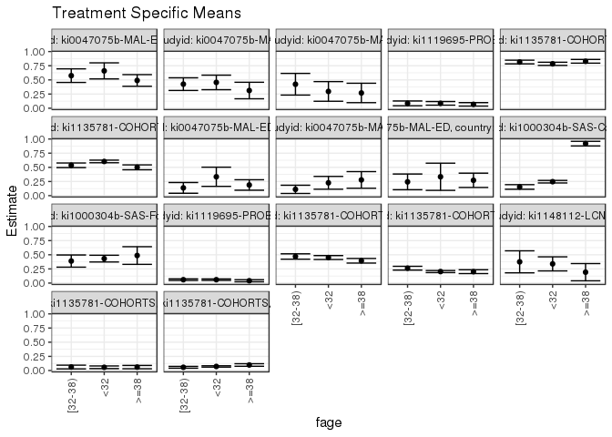

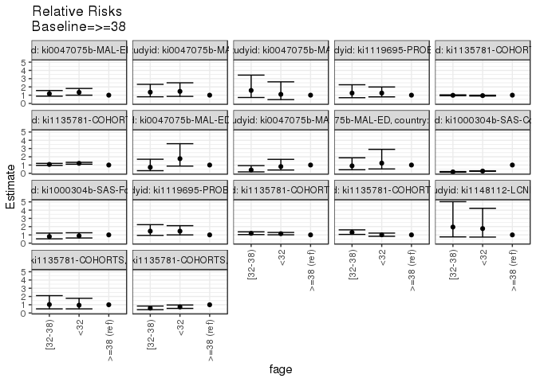

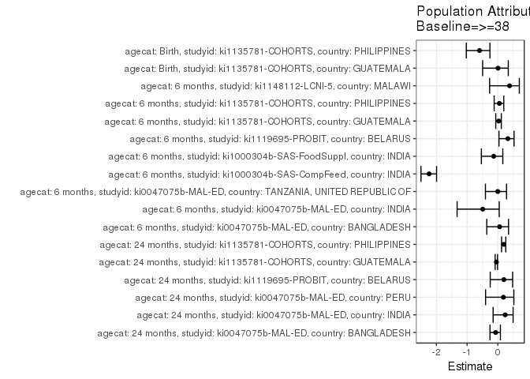

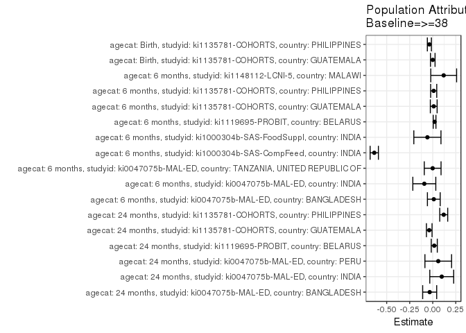

## Results Table

### Parameter: TSM

| agecat | studyid | country | intervention_level | baseline_level | estimate | ci_lower | ci_upper |
| --- | --- | --- | --- | --- | --- | --- | --- |
| Birth | ki1135781-COHORTS | GUATEMALA | >=38 | NA | 0.0603630 | 0.0309666 | 0.0897595 |
| Birth | ki1135781-COHORTS | GUATEMALA | <32 | NA | 0.0570547 | 0.0338714 | 0.0802380 |
| Birth | ki1135781-COHORTS | GUATEMALA | [32-38) | NA | 0.0619815 | 0.0294063 | 0.0945567 |
| Birth | ki1135781-COHORTS | PHILIPPINES | >=38 | NA | 0.0976227 | 0.0752309 | 0.1200146 |
| Birth | ki1135781-COHORTS | PHILIPPINES | <32 | NA | 0.0717413 | 0.0602024 | 0.0832801 |
| Birth | ki1135781-COHORTS | PHILIPPINES | [32-38) | NA | 0.0571725 | 0.0410200 | 0.0733249 |
| 6 months | ki0047075b-MAL-ED | BANGLADESH | >=38 | NA | 0.1884058 | 0.0958310 | 0.2809806 |
| 6 months | ki0047075b-MAL-ED | BANGLADESH | <32 | NA | 0.3333333 | 0.1640814 | 0.5025853 |
| 6 months | ki0047075b-MAL-ED | BANGLADESH | [32-38) | NA | 0.1372549 | 0.0424959 | 0.2320139 |
| 6 months | ki0047075b-MAL-ED | INDIA | >=38 | NA | 0.2777778 | 0.1310089 | 0.4245467 |
| 6 months | ki0047075b-MAL-ED | INDIA | <32 | NA | 0.2264151 | 0.1133913 | 0.3394389 |
| 6 months | ki0047075b-MAL-ED | INDIA | [32-38) | NA | 0.1111111 | 0.0382934 | 0.1839289 |
| 6 months | ki0047075b-MAL-ED | TANZANIA, UNITED REPUBLIC OF | >=38 | NA | 0.2708333 | 0.1444836 | 0.3971831 |
| 6 months | ki0047075b-MAL-ED | TANZANIA, UNITED REPUBLIC OF | <32 | NA | 0.3333333 | 0.0935723 | 0.5730944 |
| 6 months | ki0047075b-MAL-ED | TANZANIA, UNITED REPUBLIC OF | [32-38) | NA | 0.2432432 | 0.1043030 | 0.3821835 |
| 6 months | ki1000304b-SAS-CompFeed | INDIA | >=38 | NA | 0.9182943 | 0.8778403 | 0.9587482 |
| 6 months | ki1000304b-SAS-CompFeed | INDIA | <32 | NA | 0.2465298 | 0.2241002 | 0.2689594 |
| 6 months | ki1000304b-SAS-CompFeed | INDIA | [32-38) | NA | 0.1534790 | 0.1130462 | 0.1939118 |
| 6 months | ki1000304b-SAS-FoodSuppl | INDIA | >=38 | NA | 0.4869102 | 0.3309933 | 0.6428271 |
| 6 months | ki1000304b-SAS-FoodSuppl | INDIA | <32 | NA | 0.4318922 | 0.3723765 | 0.4914079 |
| 6 months | ki1000304b-SAS-FoodSuppl | INDIA | [32-38) | NA | 0.3890178 | 0.2816398 | 0.4963958 |
| 6 months | ki1119695-PROBIT | BELARUS | >=38 | NA | 0.0412634 | 0.0229255 | 0.0596013 |
| 6 months | ki1119695-PROBIT | BELARUS | <32 | NA | 0.0599247 | 0.0470368 | 0.0728126 |
| 6 months | ki1119695-PROBIT | BELARUS | [32-38) | NA | 0.0598912 | 0.0453199 | 0.0744625 |
| 6 months | ki1135781-COHORTS | GUATEMALA | >=38 | NA | 0.3939502 | 0.3533795 | 0.4345209 |
| 6 months | ki1135781-COHORTS | GUATEMALA | <32 | NA | 0.4511169 | 0.4167378 | 0.4854959 |
| 6 months | ki1135781-COHORTS | GUATEMALA | [32-38) | NA | 0.4693069 | 0.4221258 | 0.5164880 |
| 6 months | ki1135781-COHORTS | PHILIPPINES | >=38 | NA | 0.2014796 | 0.1678989 | 0.2350603 |
| 6 months | ki1135781-COHORTS | PHILIPPINES | <32 | NA | 0.2032840 | 0.1849040 | 0.2216640 |
| 6 months | ki1135781-COHORTS | PHILIPPINES | [32-38) | NA | 0.2628373 | 0.2294463 | 0.2962282 |
| 6 months | ki1148112-LCNI-5 | MALAWI | >=38 | NA | 0.1923077 | 0.0400985 | 0.3445169 |
| 6 months | ki1148112-LCNI-5 | MALAWI | <32 | NA | 0.3392857 | 0.2146903 | 0.4638811 |
| 6 months | ki1148112-LCNI-5 | MALAWI | [32-38) | NA | 0.3750000 | 0.1803939 | 0.5696061 |
| 24 months | ki0047075b-MAL-ED | BANGLADESH | >=38 | NA | 0.4901010 | 0.3872602 | 0.5929419 |
| 24 months | ki0047075b-MAL-ED | BANGLADESH | <32 | NA | 0.6591920 | 0.5175690 | 0.8008150 |
| 24 months | ki0047075b-MAL-ED | BANGLADESH | [32-38) | NA | 0.5746475 | 0.4547795 | 0.6945155 |
| 24 months | ki0047075b-MAL-ED | INDIA | >=38 | NA | 0.3122940 | 0.1663866 | 0.4582015 |
| 24 months | ki0047075b-MAL-ED | INDIA | <32 | NA | 0.4554144 | 0.3268126 | 0.5840162 |
| 24 months | ki0047075b-MAL-ED | INDIA | [32-38) | NA | 0.4249335 | 0.3131192 | 0.5367478 |
| 24 months | ki0047075b-MAL-ED | PERU | >=38 | NA | 0.2692308 | 0.0976454 | 0.4408161 |
| 24 months | ki0047075b-MAL-ED | PERU | <32 | NA | 0.2962963 | 0.1229596 | 0.4696330 |
| 24 months | ki0047075b-MAL-ED | PERU | [32-38) | NA | 0.4230769 | 0.2319613 | 0.6141926 |
| 24 months | ki1119695-PROBIT | BELARUS | >=38 | NA | 0.0682970 | 0.0381815 | 0.0984125 |
| 24 months | ki1119695-PROBIT | BELARUS | <32 | NA | 0.0858285 | 0.0540541 | 0.1176028 |
| 24 months | ki1119695-PROBIT | BELARUS | [32-38) | NA | 0.0854968 | 0.0434884 | 0.1275052 |
| 24 months | ki1135781-COHORTS | GUATEMALA | >=38 | NA | 0.8280234 | 0.7953518 | 0.8606950 |
| 24 months | ki1135781-COHORTS | GUATEMALA | <32 | NA | 0.7837350 | 0.7561152 | 0.8113549 |
| 24 months | ki1135781-COHORTS | GUATEMALA | [32-38) | NA | 0.8154870 | 0.7832243 | 0.8477496 |
| 24 months | ki1135781-COHORTS | PHILIPPINES | >=38 | NA | 0.5002648 | 0.4569877 | 0.5435420 |
| 24 months | ki1135781-COHORTS | PHILIPPINES | <32 | NA | 0.6036227 | 0.5806456 | 0.6265998 |
| 24 months | ki1135781-COHORTS | PHILIPPINES | [32-38) | NA | 0.5362417 | 0.4956955 | 0.5767878 |

### Parameter: E(Y)

| agecat | studyid | country | intervention_level | baseline_level | estimate | ci_lower | ci_upper |
| --- | --- | --- | --- | --- | --- | --- | --- |
| Birth | ki1135781-COHORTS | GUATEMALA | NA | NA | 0.0607533 | 0.0444233 | 0.0770834 |
| Birth | ki1135781-COHORTS | PHILIPPINES | NA | NA | 0.0611413 | 0.0524852 | 0.0697974 |
| 6 months | ki0047075b-MAL-ED | BANGLADESH | NA | NA | 0.2000000 | 0.1357734 | 0.2642266 |
| 6 months | ki0047075b-MAL-ED | INDIA | NA | NA | 0.1863354 | 0.1260019 | 0.2466689 |
| 6 months | ki0047075b-MAL-ED | TANZANIA, UNITED REPUBLIC OF | NA | NA | 0.2700000 | 0.1825472 | 0.3574528 |
| 6 months | ki1000304b-SAS-CompFeed | INDIA | NA | NA | 0.2835709 | 0.2656121 | 0.3015297 |
| 6 months | ki1000304b-SAS-FoodSuppl | INDIA | NA | NA | 0.4289474 | 0.3791199 | 0.4787748 |
| 6 months | ki1119695-PROBIT | BELARUS | NA | NA | 0.0611869 | 0.0477477 | 0.0746260 |
| 6 months | ki1135781-COHORTS | GUATEMALA | NA | NA | 0.4047363 | 0.3731561 | 0.4363165 |
| 6 months | ki1135781-COHORTS | PHILIPPINES | NA | NA | 0.2118902 | 0.1962516 | 0.2275288 |
| 6 months | ki1148112-LCNI-5 | MALAWI | NA | NA | 0.3113208 | 0.2227550 | 0.3998865 |
| 24 months | ki0047075b-MAL-ED | BANGLADESH | NA | NA | 0.4569536 | 0.3772355 | 0.5366718 |
| 24 months | ki0047075b-MAL-ED | INDIA | NA | NA | 0.4099379 | 0.3337307 | 0.4861451 |
| 24 months | ki0047075b-MAL-ED | PERU | NA | NA | 0.3291139 | 0.2248346 | 0.4333933 |
| 24 months | ki1119695-PROBIT | BELARUS | NA | NA | 0.0849322 | 0.0549995 | 0.1148649 |
| 24 months | ki1135781-COHORTS | GUATEMALA | NA | NA | 0.7900391 | 0.7650814 | 0.8149967 |
| 24 months | ki1135781-COHORTS | PHILIPPINES | NA | NA | 0.6195698 | 0.6000239 | 0.6391157 |

### Parameter: RR

| agecat | studyid | country | intervention_level | baseline_level | estimate | ci_lower | ci_upper |
| --- | --- | --- | --- | --- | --- | --- | --- |
| Birth | ki1135781-COHORTS | GUATEMALA | >=38 | >=38 | 1.0000000 | 1.0000000 | 1.0000000 |
| Birth | ki1135781-COHORTS | GUATEMALA | <32 | >=38 | 0.9451932 | 0.5013221 | 1.7820680 |
| Birth | ki1135781-COHORTS | GUATEMALA | [32-38) | >=38 | 1.0268123 | 0.5014302 | 2.1026722 |
| Birth | ki1135781-COHORTS | PHILIPPINES | >=38 | >=38 | 1.0000000 | 1.0000000 | 1.0000000 |
| Birth | ki1135781-COHORTS | PHILIPPINES | <32 | >=38 | 0.7348826 | 0.5562830 | 0.9708230 |
| Birth | ki1135781-COHORTS | PHILIPPINES | [32-38) | >=38 | 0.5856469 | 0.4073167 | 0.8420530 |
| 6 months | ki0047075b-MAL-ED | BANGLADESH | >=38 | >=38 | 1.0000000 | 1.0000000 | 1.0000000 |
| 6 months | ki0047075b-MAL-ED | BANGLADESH | <32 | >=38 | 1.7692308 | 0.8728158 | 3.5862980 |
| 6 months | ki0047075b-MAL-ED | BANGLADESH | [32-38) | >=38 | 0.7285068 | 0.3121888 | 1.7000037 |
| 6 months | ki0047075b-MAL-ED | INDIA | >=38 | >=38 | 1.0000000 | 1.0000000 | 1.0000000 |
| 6 months | ki0047075b-MAL-ED | INDIA | <32 | >=38 | 0.8150943 | 0.3940268 | 1.6861258 |
| 6 months | ki0047075b-MAL-ED | INDIA | [32-38) | >=38 | 0.4000000 | 0.1723694 | 0.9282392 |
| 6 months | ki0047075b-MAL-ED | TANZANIA, UNITED REPUBLIC OF | >=38 | >=38 | 1.0000000 | 1.0000000 | 1.0000000 |
| 6 months | ki0047075b-MAL-ED | TANZANIA, UNITED REPUBLIC OF | <32 | >=38 | 1.2307692 | 0.5222084 | 2.9007439 |
| 6 months | ki0047075b-MAL-ED | TANZANIA, UNITED REPUBLIC OF | [32-38) | >=38 | 0.8981289 | 0.4295810 | 1.8777263 |
| 6 months | ki1000304b-SAS-CompFeed | INDIA | >=38 | >=38 | 1.0000000 | 1.0000000 | 1.0000000 |
| 6 months | ki1000304b-SAS-CompFeed | INDIA | <32 | >=38 | 0.2684649 | 0.2411072 | 0.2989268 |
| 6 months | ki1000304b-SAS-CompFeed | INDIA | [32-38) | >=38 | 0.1671349 | 0.1333952 | 0.2094083 |
| 6 months | ki1000304b-SAS-FoodSuppl | INDIA | >=38 | >=38 | 1.0000000 | 1.0000000 | 1.0000000 |
| 6 months | ki1000304b-SAS-FoodSuppl | INDIA | <32 | >=38 | 0.8870059 | 0.6261626 | 1.2565098 |
| 6 months | ki1000304b-SAS-FoodSuppl | INDIA | [32-38) | >=38 | 0.7989519 | 0.5237203 | 1.2188263 |
| 6 months | ki1119695-PROBIT | BELARUS | >=38 | >=38 | 1.0000000 | 1.0000000 | 1.0000000 |
| 6 months | ki1119695-PROBIT | BELARUS | <32 | >=38 | 1.4522483 | 0.9972475 | 2.1148463 |
| 6 months | ki1119695-PROBIT | BELARUS | [32-38) | >=38 | 1.4514373 | 0.9400641 | 2.2409857 |
| 6 months | ki1135781-COHORTS | GUATEMALA | >=38 | >=38 | 1.0000000 | 1.0000000 | 1.0000000 |
| 6 months | ki1135781-COHORTS | GUATEMALA | <32 | >=38 | 1.1451115 | 1.0133113 | 1.2940548 |
| 6 months | ki1135781-COHORTS | GUATEMALA | [32-38) | >=38 | 1.1912849 | 1.0365373 | 1.3691352 |
| 6 months | ki1135781-COHORTS | PHILIPPINES | >=38 | >=38 | 1.0000000 | 1.0000000 | 1.0000000 |
| 6 months | ki1135781-COHORTS | PHILIPPINES | <32 | >=38 | 1.0089558 | 0.8357276 | 1.2180906 |
| 6 months | ki1135781-COHORTS | PHILIPPINES | [32-38) | >=38 | 1.3045355 | 1.0584689 | 1.6078062 |
| 6 months | ki1148112-LCNI-5 | MALAWI | >=38 | >=38 | 1.0000000 | 1.0000000 | 1.0000000 |
| 6 months | ki1148112-LCNI-5 | MALAWI | <32 | >=38 | 1.7642857 | 0.7372819 | 4.2218641 |
| 6 months | ki1148112-LCNI-5 | MALAWI | [32-38) | >=38 | 1.9500000 | 0.7568292 | 5.0242509 |
| 24 months | ki0047075b-MAL-ED | BANGLADESH | >=38 | >=38 | 1.0000000 | 1.0000000 | 1.0000000 |
| 24 months | ki0047075b-MAL-ED | BANGLADESH | <32 | >=38 | 1.3450124 | 0.9990060 | 1.8108585 |
| 24 months | ki0047075b-MAL-ED | BANGLADESH | [32-38) | >=38 | 1.1725083 | 0.8816482 | 1.5593245 |
| 24 months | ki0047075b-MAL-ED | INDIA | >=38 | >=38 | 1.0000000 | 1.0000000 | 1.0000000 |
| 24 months | ki0047075b-MAL-ED | INDIA | <32 | >=38 | 1.4582872 | 0.8511502 | 2.4985035 |
| 24 months | ki0047075b-MAL-ED | INDIA | [32-38) | >=38 | 1.3606840 | 0.8002960 | 2.3134703 |
| 24 months | ki0047075b-MAL-ED | PERU | >=38 | >=38 | 1.0000000 | 1.0000000 | 1.0000000 |
| 24 months | ki0047075b-MAL-ED | PERU | <32 | >=38 | 1.1005291 | 0.4633297 | 2.6140444 |
| 24 months | ki0047075b-MAL-ED | PERU | [32-38) | >=38 | 1.5714286 | 0.7195080 | 3.4320507 |
| 24 months | ki1119695-PROBIT | BELARUS | >=38 | >=38 | 1.0000000 | 1.0000000 | 1.0000000 |
| 24 months | ki1119695-PROBIT | BELARUS | <32 | >=38 | 1.2566942 | 0.7934473 | 1.9904036 |
| 24 months | ki1119695-PROBIT | BELARUS | [32-38) | >=38 | 1.2518375 | 0.6929176 | 2.2615921 |
| 24 months | ki1135781-COHORTS | GUATEMALA | >=38 | >=38 | 1.0000000 | 1.0000000 | 1.0000000 |
| 24 months | ki1135781-COHORTS | GUATEMALA | <32 | >=38 | 0.9465132 | 0.8990414 | 0.9964915 |
| 24 months | ki1135781-COHORTS | GUATEMALA | [32-38) | >=38 | 0.9848598 | 0.9326361 | 1.0400078 |
| 24 months | ki1135781-COHORTS | PHILIPPINES | >=38 | >=38 | 1.0000000 | 1.0000000 | 1.0000000 |
| 24 months | ki1135781-COHORTS | PHILIPPINES | <32 | >=38 | 1.2066063 | 1.0988001 | 1.3249897 |
| 24 months | ki1135781-COHORTS | PHILIPPINES | [32-38) | >=38 | 1.0719156 | 0.9572884 | 1.2002684 |

### Parameter: PAR

| agecat | studyid | country | intervention_level | baseline_level | estimate | ci_lower | ci_upper |
| --- | --- | --- | --- | --- | --- | --- | --- |
| Birth | ki1135781-COHORTS | GUATEMALA | >=38 | NA | 0.0003903 | -0.0242602 | 0.0250408 |
| Birth | ki1135781-COHORTS | PHILIPPINES | >=38 | NA | -0.0364814 | -0.0584440 | -0.0145188 |
| 6 months | ki0047075b-MAL-ED | BANGLADESH | >=38 | NA | 0.0115942 | -0.0577647 | 0.0809531 |
| 6 months | ki0047075b-MAL-ED | INDIA | >=38 | NA | -0.0914424 | -0.2161338 | 0.0332490 |
| 6 months | ki0047075b-MAL-ED | TANZANIA, UNITED REPUBLIC OF | >=38 | NA | -0.0008333 | -0.0918639 | 0.0901972 |
| 6 months | ki1000304b-SAS-CompFeed | INDIA | >=38 | NA | -0.6347234 | -0.6795305 | -0.5899162 |
| 6 months | ki1000304b-SAS-FoodSuppl | INDIA | >=38 | NA | -0.0579628 | -0.2053327 | 0.0894071 |
| 6 months | ki1119695-PROBIT | BELARUS | >=38 | NA | 0.0199235 | 0.0051612 | 0.0346857 |
| 6 months | ki1135781-COHORTS | GUATEMALA | >=38 | NA | 0.0107861 | -0.0259875 | 0.0475597 |
| 6 months | ki1135781-COHORTS | PHILIPPINES | >=38 | NA | 0.0104107 | -0.0227039 | 0.0435252 |
| 6 months | ki1148112-LCNI-5 | MALAWI | >=38 | NA | 0.1190131 | -0.0211521 | 0.2591783 |
| 24 months | ki0047075b-MAL-ED | BANGLADESH | >=38 | NA | -0.0331474 | -0.1092164 | 0.0429216 |
| 24 months | ki0047075b-MAL-ED | INDIA | >=38 | NA | 0.0976439 | -0.0320166 | 0.2273044 |
| 24 months | ki0047075b-MAL-ED | PERU | >=38 | NA | 0.0598832 | -0.0848113 | 0.2045776 |
| 24 months | ki1119695-PROBIT | BELARUS | >=38 | NA | 0.0166352 | -0.0161504 | 0.0494208 |
| 24 months | ki1135781-COHORTS | GUATEMALA | >=38 | NA | -0.0379843 | -0.0684297 | -0.0075390 |
| 24 months | ki1135781-COHORTS | PHILIPPINES | >=38 | NA | 0.1193050 | 0.0760941 | 0.1625159 |

### Parameter: PAF

| agecat | studyid | country | intervention_level | baseline_level | estimate | ci_lower | ci_upper |
| --- | --- | --- | --- | --- | --- | --- | --- |
| Birth | ki1135781-COHORTS | GUATEMALA | >=38 | NA | 0.0064247 | -0.4946721 | 0.3395262 |
| Birth | ki1135781-COHORTS | PHILIPPINES | >=38 | NA | -0.5966743 | -1.0268533 | -0.2577964 |
| 6 months | ki0047075b-MAL-ED | BANGLADESH | >=38 | NA | 0.0579710 | -0.3608861 | 0.3479112 |
| 6 months | ki0047075b-MAL-ED | INDIA | >=38 | NA | -0.4907407 | -1.3259527 | 0.0445601 |
| 6 months | ki0047075b-MAL-ED | TANZANIA, UNITED REPUBLIC OF | >=38 | NA | -0.0030864 | -0.4038159 | 0.2832519 |
| 6 months | ki1000304b-SAS-CompFeed | INDIA | >=38 | NA | -2.2383234 | -2.5022411 | -1.9942936 |
| 6 months | ki1000304b-SAS-FoodSuppl | INDIA | >=38 | NA | -0.1351281 | -0.5366760 | 0.1614916 |
| 6 months | ki1119695-PROBIT | BELARUS | >=38 | NA | 0.3256169 | 0.0364423 | 0.5280070 |
| 6 months | ki1135781-COHORTS | GUATEMALA | >=38 | NA | 0.0266497 | -0.0679167 | 0.1128421 |
| 6 months | ki1135781-COHORTS | PHILIPPINES | >=38 | NA | 0.0491324 | -0.1198929 | 0.1926466 |
| 6 months | ki1148112-LCNI-5 | MALAWI | >=38 | NA | 0.3822844 | -0.2683064 | 0.6991479 |
| 24 months | ki0047075b-MAL-ED | BANGLADESH | >=38 | NA | -0.0725400 | -0.2550800 | 0.0834513 |
| 24 months | ki0047075b-MAL-ED | INDIA | >=38 | NA | 0.2381918 | -0.1540556 | 0.4971198 |
| 24 months | ki0047075b-MAL-ED | PERU | >=38 | NA | 0.1819527 | -0.3989032 | 0.5216242 |
| 24 months | ki1119695-PROBIT | BELARUS | >=38 | NA | 0.1958644 | -0.2479302 | 0.4818347 |
| 24 months | ki1135781-COHORTS | GUATEMALA | >=38 | NA | -0.0480791 | -0.0878607 | -0.0097522 |
| 24 months | ki1135781-COHORTS | PHILIPPINES | >=38 | NA | 0.1925610 | 0.1209125 | 0.2583699 |